# Titanic Survival Prediction

JeffreyChen

2018/5/2

# 1 摘要

首先，我分析決定生還或決定罹難的變數，發現乘客有沒有上救生艇是很重要的變數。  
當然為了預測，我也用了很多其他的變數(例如稱謂、性別等等)，提高準確率。  
在學習方面，我使用的是隨機樹(Random Forest)。

# 2 載入資料及探討變數決定生還的重要性

## 2.1 載入所需的library

```r
library('gridExtra')
library('ggplot2')
library('ggthemes')
library('scales')
library('dplyr')
library('mice')
library('randomForest')
```

## 2.2 載入訓練及測試資料

```r
# 讀檔（訓練集及測試集）
train.data <- read.csv("titanicTrain.csv", stringsAsFactors = F, na.strings = c(""))
test.data <- read.csv("titanicQuestion.csv", stringsAsFactors = F, na.strings = c(""))
train.data <- train.data[1:1000, ]
test.data <- test.data[1:309, ]
full <- rbind(train.data, test.data)
str(full)
```

```
## 'data.frame':    1309 obs. of  14 variables:
##  $ pclass   : int  1 1 1 1 1 1 1 1 1 1 ...
##  $ survived : int  1 1 0 0 0 1 1 0 1 0 ...
##  $ name     : chr  "Allen, Miss. Elisabeth Walton" "Allison, Master. Hudson Trevor" "Allison, Miss. Helen Loraine" "Allison, Mr. Hudson Joshua Creighton" ...
##  $ sex      : chr  "female" "male" "female" "male" ...
##  $ age      : num  29 0.917 2 30 25 ...
##  $ sibsp    : int  0 1 1 1 1 0 1 0 2 0 ...
##  $ parch    : int  0 2 2 2 2 0 0 0 0 0 ...
##  $ ticket   : chr  "24160" "113781" "113781" "113781" ...
##  $ fare     : num  211 152 152 152 152 ...
##  $ cabin    : chr  "B5" "C22 C26" "C22 C26" "C22 C26" ...
##  $ embarked : chr  "S" "S" "S" "S" ...
##  $ boat     : chr  "2" "11" NA NA ...
##  $ body     : int  NA NA NA 135 NA NA NA NA NA 22 ...
##  $ home.dest: chr  "St Louis, MO" "Montreal, PQ / Chesterville, ON" "Montreal, PQ / Chesterville, ON" "Montreal, PQ / Chesterville, ON" ...
```

```r
full$survived <- as.factor(full$survived)
full$pclass <- as.factor(full$pclass)
full$sex <- as.factor(full$sex)
train <- full[1:1000,]
```

## 2.3 分析什麼樣的人為生還者的機率較高

### 2.3.1 生還人數

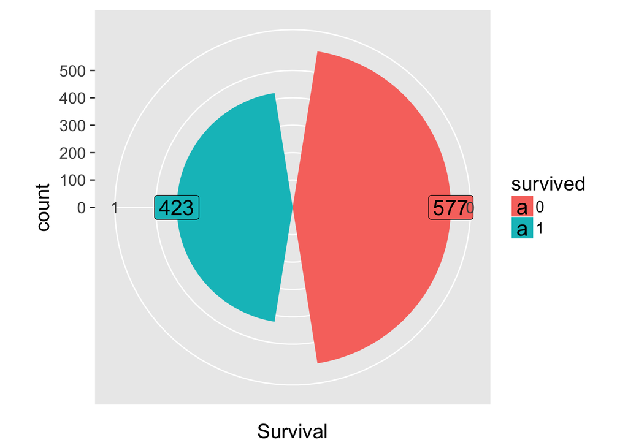

```r
# 生還人數
ggplot(train, aes(x = survived, fill = survived)) +
  geom_bar(stat = 'count') +
  labs(x = 'Survival') +
  geom_label(stat = 'count',aes(label = ..count..), size = 6) +
  theme_grey(base_size = 16) +
  coord_polar("x", start=0)
```

### 2.3.2 探討性別及小孩和生還之間的關係

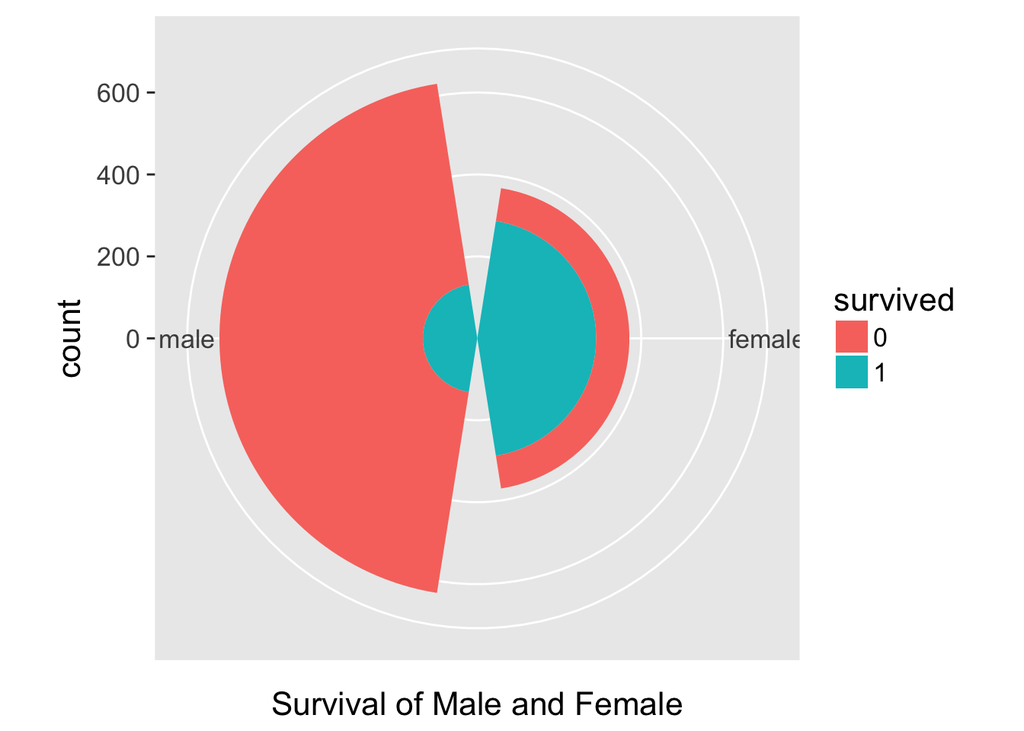

```r
# 男女小孩生還比較
ggplot(train, aes(x = sex, fill = survived)) +
  geom_bar(stat = 'count') +
  labs(x = 'Survival of Male and Female') +
  theme_grey(base_size = 16) +
  coord_polar("x", start=0)
```

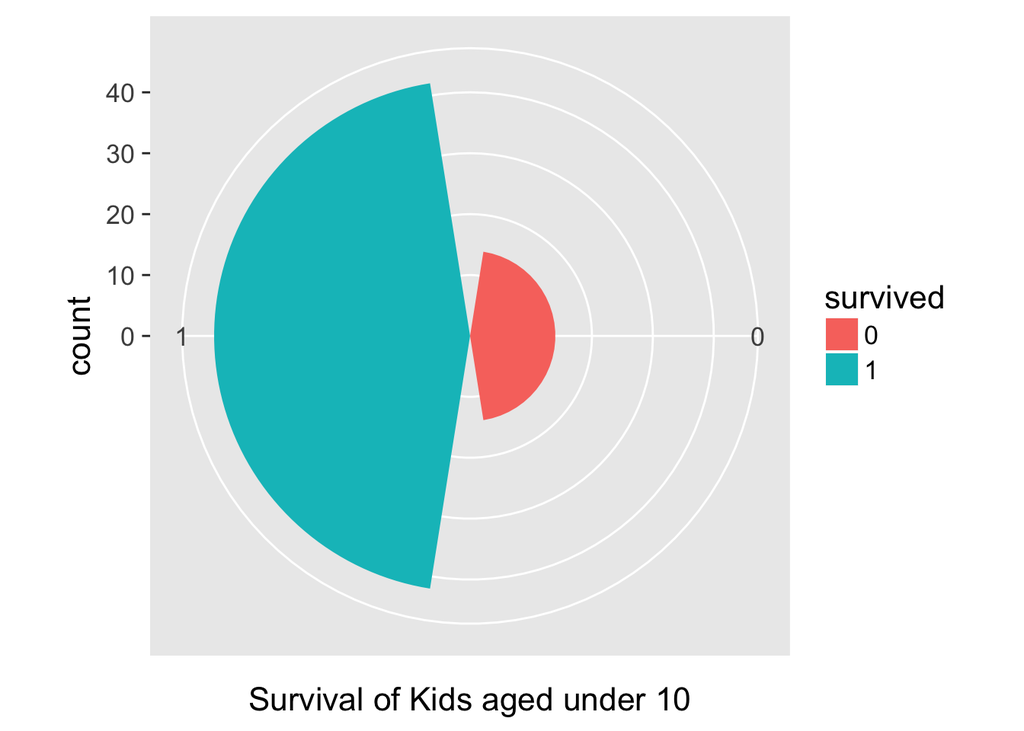

```r
kids.survival <- train[(!is.na(train$age)) & (train$age < 10), ]
ggplot(kids.survival, aes(x = survived, fill = survived)) +
  geom_bar(stat = 'count') +
  labs(x = 'Survival of Kids aged under 10') +
  theme_grey(base_size = 16) +
  coord_polar("x", start=0)
```

可以看出男人的生還率最低，女人及小孩的生還率較高。

### 2.3.3 探討座艙等級和生還之間的關係

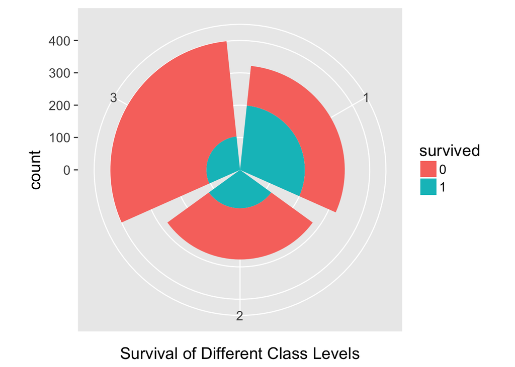

```r
#依照座艙等級分類
ggplot(train, aes(x = pclass, fill = survived)) +
  geom_bar(stat = 'count') +
  labs(x = 'Survival of Different Class Levels') +
  theme_grey(base_size = 16) +
  coord_polar("x", start=0)
```

可以發現座艙等級越高，生還率越高。

### 2.3.4 探討上船與否和生還之間的關係

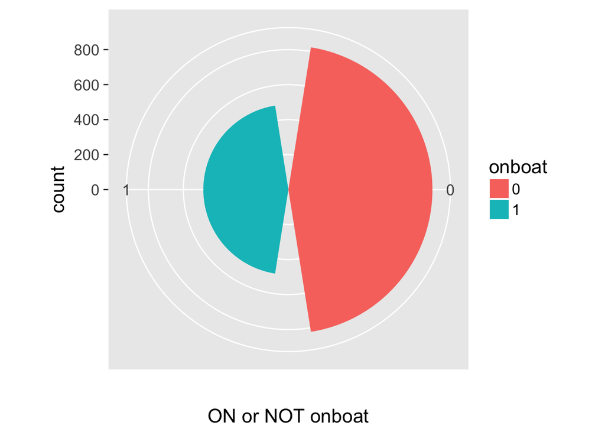

```r
full[!is.na(full$boat), "onboat"] <- "1"
full[is.na(full$boat), "onboat"] <- "0"

ggplot(full, aes(x = onboat, fill = onboat)) +
  geom_bar(stat = 'count') +
  labs(x = '\nON or NOT onboat') +
  theme_grey(base_size = 16) +
  coord_polar("x", start=0)
```

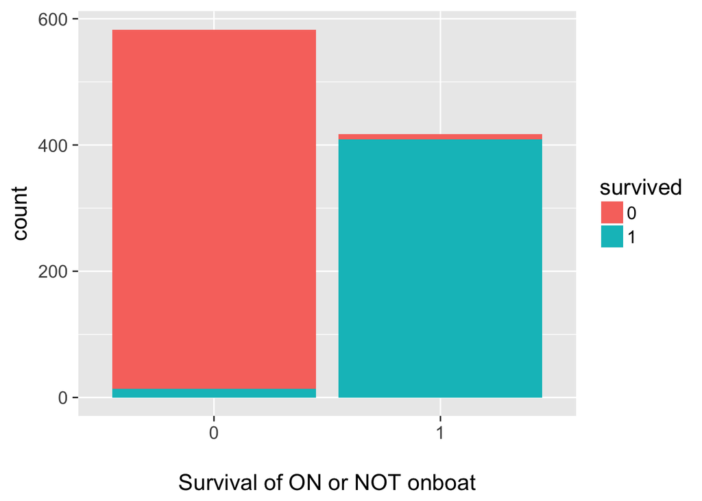

```r
ggplot(full[1:1000,], aes(x = onboat, fill = survived)) +
  geom_bar(stat = 'count') +
  labs(x = '\nSurvival of ON or NOT onboat') +
  theme_grey(base_size = 16)
```

上船者有很大的機率生還，反之則難逃一劫。

## 2.4 探討上救生艇的人都是些什麼人

### 2.4.1 性別和上船與否的關係

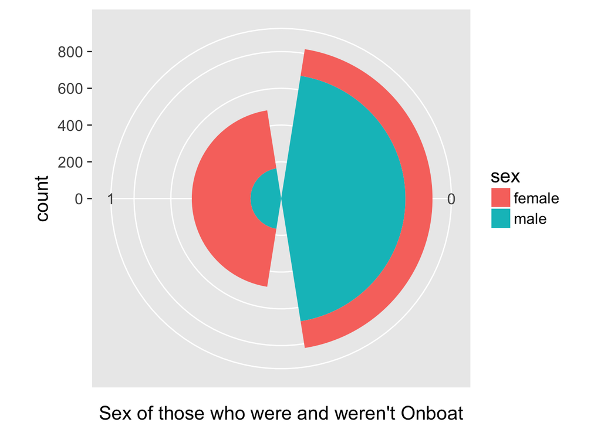

```r
MF.OB <- ggplot(full, aes(x = onboat, fill = sex)) +
  geom_bar(stat = 'count') +
  labs(x = 'Sex of those who were and weren\'t Onboat') +
  theme_grey(base_size = 16) +
  coord_polar("x", start=0)
MF.OB
```

上船者有一大部分是女人，沒上船的有一大部分是男人。

### 2.4.2 座艙等級和上船與否的關係

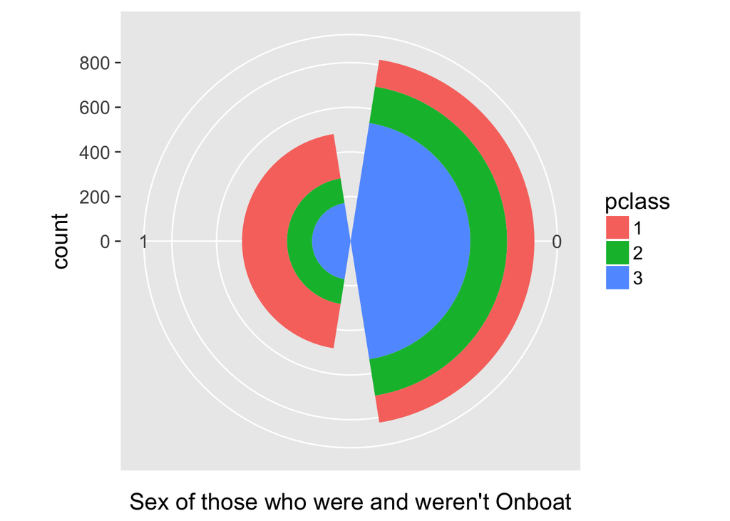

```r
CL.OB <- ggplot(full, aes(x = onboat, fill = pclass)) +
  geom_bar(stat = 'count') +
  labs(x = 'Sex of those who were and weren\'t Onboat') +
  theme_grey(base_size = 16) +
  coord_polar("x", start=0)
CL.OB
```

上船者有一大部分是座艙等級最高的，沒上船的有一半是座艙等級最低的。

### 2.4.3 年齡和上船與否的關係

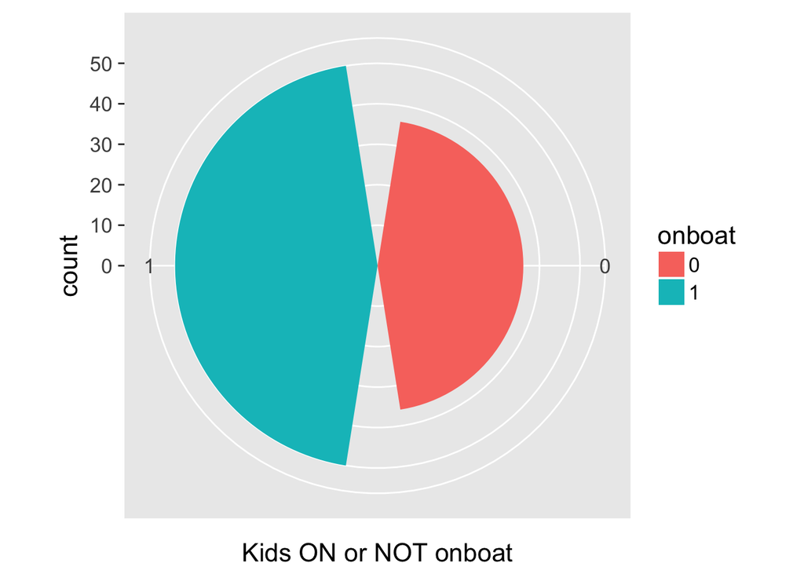

```r
full$age <- floor(full$age)
ggplot(full[!is.na(full$age) & (full$age <= 10),], aes(x = onboat, fill = onboat)) +
  geom_bar(stat = 'count') +
  labs(x = 'Kids ON or NOT onboat') +
  theme_grey(base_size = 16) +
  coord_polar("x", start=0)
```

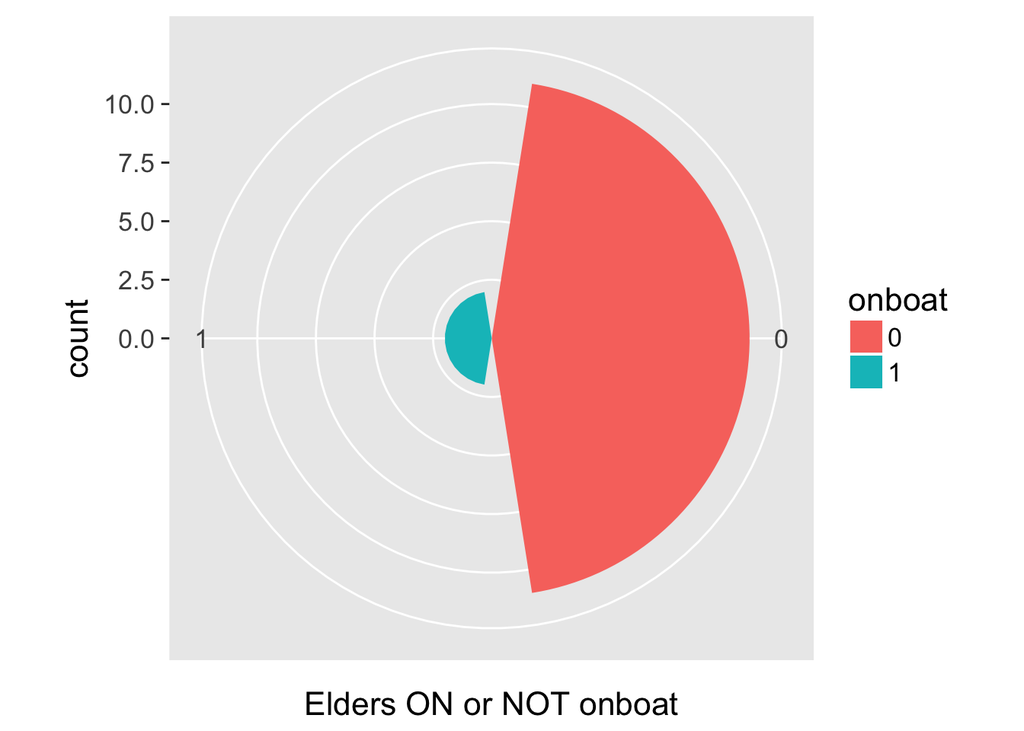

```r
ggplot(full[!is.na(full$age) & (full$age >= 65),], aes(x = onboat, fill = onboat)) +
  geom_bar(stat = 'count') +
  labs(x = 'Elders ON or NOT onboat') +
  theme_grey(base_size = 16) +
  coord_polar("x", start=0)
```

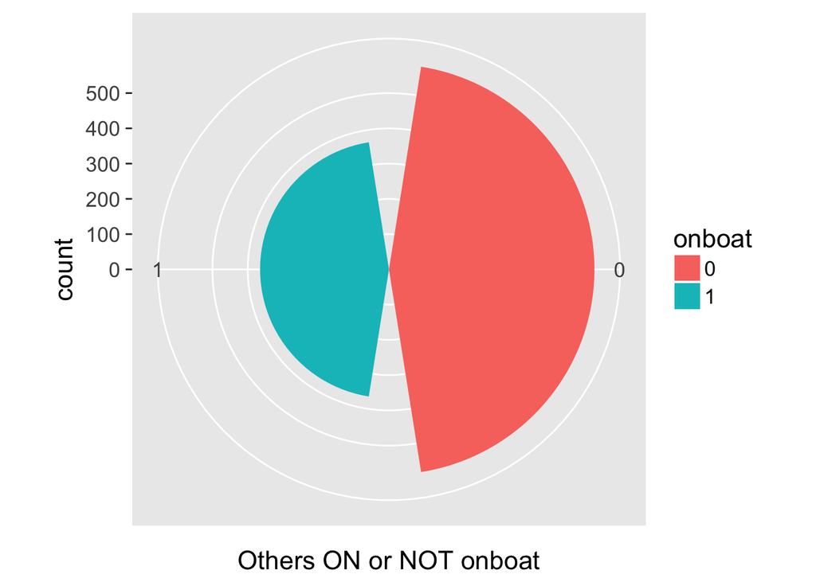

```r
ggplot(full[!is.na(full$age) & (full$age < 65) & (full$age > 10),], aes(x = onboat, fill = onboat)) +
  geom_bar(stat = 'count') +
  labs(x = 'Others ON or NOT onboat') +
  theme_grey(base_size = 16) +
  coord_polar("x", start=0)
```

發現小孩蠻多有上船，老人大多沒上船，其他人則為沒上船者多一些。

## 2.5 找出新變量

### 2.5.1 觀察稱謂變量

```r
# 從乘客名字中提取稱謂
full$title <- gsub('(.*, )|(\\..*)', '', full$name)
# 查看按照性別劃分的稱謂數量
table(full$sex, full$title)
```

```
##
##          Capt Col Don Dona  Dr Jonkheer Lady Major Master Miss Mlle Mme
##   female    0   0   0    1   1        0    1     0      0  260    2   1
##   male      1   4   1    0   7        1    0     2     61    0    0   0
##
##           Mr Mrs  Ms Rev Sir the Countess
##   female   0 197   2   0   0            1
##   male   757   0   0   8   1            0
```

```r
# 對於那些出現頻率較低的稱謂合併為一類
rare_title <- c('Dona', 'Lady', 'the Countess','Capt', 'Col', 'Don', 'Dr', 'Major', 'Rev', 'Sir', 'Jonkheer', 'Mme')
full$title[full$title == 'Mlle']<- 'Miss'
full$title[full$title == 'Ms'] <- 'Miss'
full$title[full$title %in% rare_title] <- 'Rare Title'
table(full$sex, full$title)
```

```
##
##          Master Miss  Mr Mrs Rare Title
##   female      0  264   0 197          5
##   male       61    0 757   0         25
```

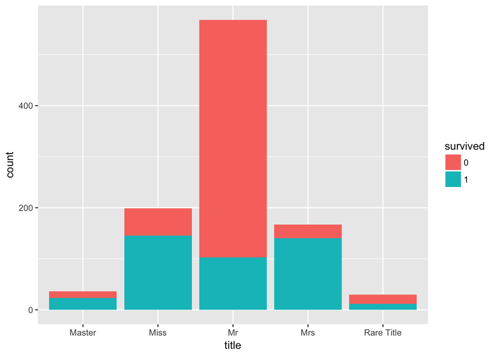

```r
ggplot(full[1:1000,]) +
  geom_histogram(aes(x = title, fill = survived), stat="count")
```

可得知女性稱謂生還率較高，女性生還率高（符合前述事實）。

```r
full$surname <- sapply(full$name, function(x) strsplit(x, split = '[,.]')[[1]][1])
```

最後從乘客姓名中，提取姓氏。

### 2.5.2 觀察家庭大小變量

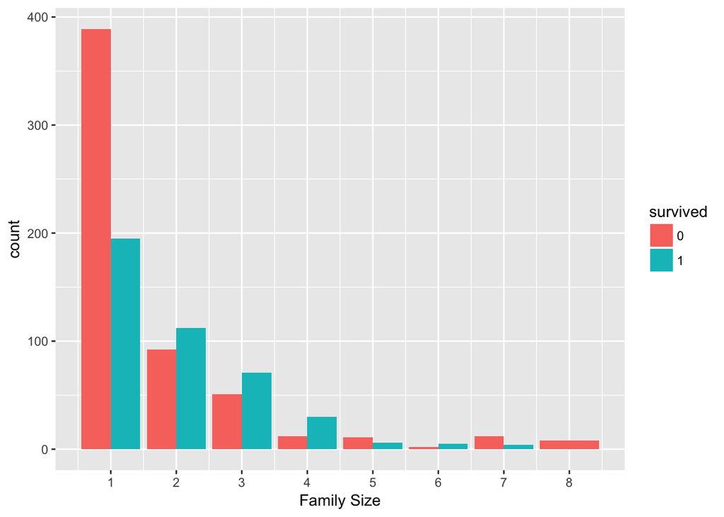

```r
full$familycount <- full$sibsp + full$parch + 1

ggplot(full[1:1000, ], aes(x = familycount, fill = survived)) +
  geom_bar(stat='count', position='dodge') +
  scale_x_continuous(breaks=c(1:8)) + labs(x = 'Family Size') +
  theme_gray()
```

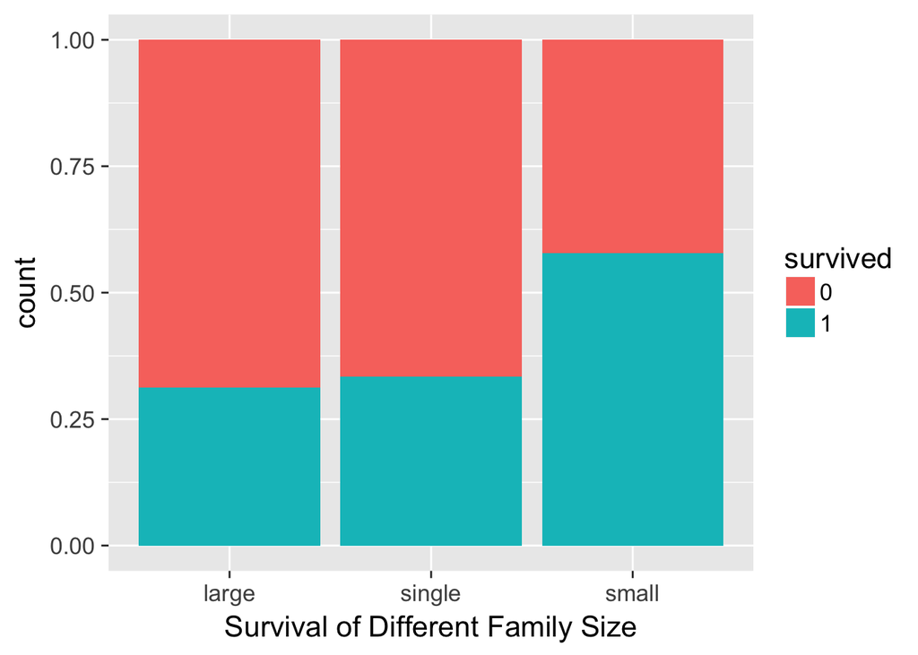

```r
full$familysize[full$familycount == 1] <- 'single'
full$familysize[full$familycount < 5 & full$familycount > 1]<- 'small'
full$familysize[full$familycount > 4] <- 'large'

ggplot(full[1:1000, ], aes(x = familysize, fill = survived)) +
  geom_bar(stat = 'count', position = 'fill') +
  labs(x = 'Survival of Different Family Size') +
  theme_grey(base_size = 16)
```

一個人的罹難率高，家庭人數二到四（小家庭）的生存率最高，家庭人數四個以上（大家庭）生存率低。

# 3 填補缺失值

## 3.1 填補出發港口（embarked）缺失值

```r
sum(is.na(full$embarked))
```

```
## [1] 2
```

```r
full[is.na(full$embarked),]
```

```
##     pclass survived                                      name    sex age
## 169      1        1                       Icard, Miss. Amelie female  38
## 285      1        1 Stone, Mrs. George Nelson (Martha Evelyn) female  62
##     sibsp parch ticket fare cabin embarked boat body      home.dest onboat
## 169     0     0 113572   80   B28     <NA>    6   NA           <NA>      1
## 285     0     0 113572   80   B28     <NA>    6   NA Cincinatti, OH      1
##     title surname familycount familysize
## 169  Miss   Icard           1     single
## 285   Mrs   Stone           1     single
```

發現有兩行有缺失值：第169和第285行

我估計對於有相同艙位等級（pclass）和票價（fare）的乘客也許有著相同的登船港口位置( embarked)

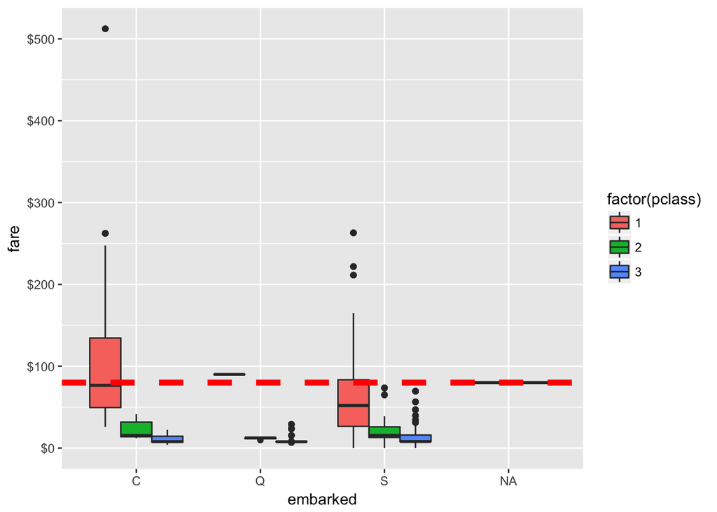

```r
ggplot(full, aes(x = embarked, y = fare, fill = factor(pclass))) +
  geom_boxplot() +
  geom_hline(aes(yintercept=80), colour='red', linetype='dashed', lwd=2) +
  scale_y_continuous(labels=dollar_format()) +
  theme_gray()
```

港口Ｃ的票價的中位數為80，因此我們可以把乘客169, 285的出發港口缺失值替換為‘Ｃ’

```r
full[c(169, 285),"embarked"] <- 'C'
```

## 3.2 填補票價（fare）缺失值

```r
sum(is.na(full$fare))
```

```
## [1] 1
```

```r
full[is.na(full$fare),]
```

```
##      pclass survived               name  sex age sibsp parch ticket fare
## 1226      3     <NA> Storey, Mr. Thomas male  60     0     0   3701   NA
##      cabin embarked boat body home.dest onboat title surname familycount
## 1226  <NA>        S <NA>  261      <NA>      0    Mr  Storey           1
##      familysize
## 1226     single
```

有一個缺失值，在第1226行。  
這位乘客是座艙等級3且出發港口為Ｓ，所以我決定找出有同樣條件的人的票價的中位數，當作此缺失值之票價。

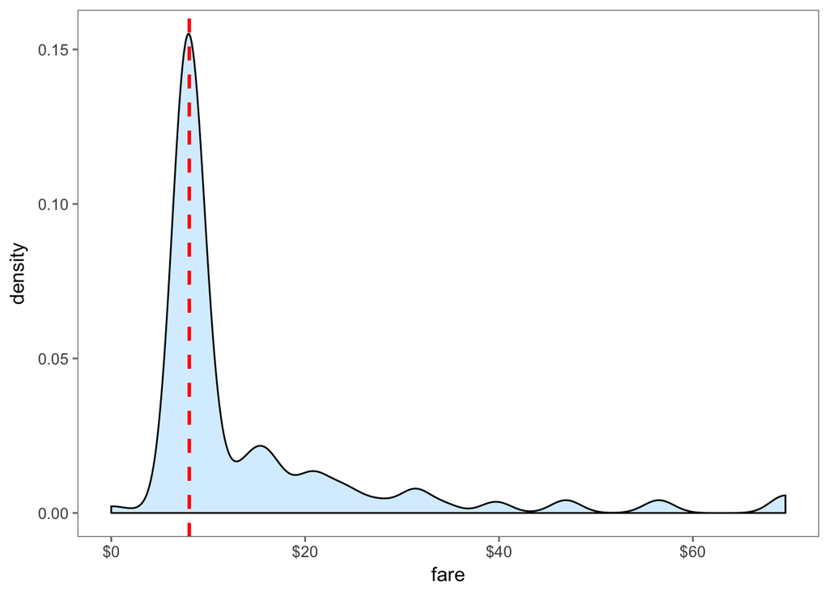

```r
ggplot(full[full$pclass == '3' & full$embarked == 'S', ], aes(x = fare)) +
  geom_density(fill = '#99d6ff', alpha=0.4) +
  geom_vline(aes(xintercept=median(fare, na.rm=T)),colour='red', linetype='dashed', lwd=1) +
  scale_x_continuous(labels=dollar_format()) +
  theme_few()
```

```r
median(full[!is.na(full$fare) & (full$embarked == 'S') & (full$pclass == '3'), "fare"])
```

```
## [1] 8.05
```

找出中位數大概在8左右，我們用median函數找出實際值，為8.05。

```r
full[1226,"fare"] <- median(full[!is.na(full$fare) & (full$embarked == 'S') & (full$pclass == '3'), "fare"])
```

把此乘客的票價設定為同樣條件的人的票價的中位數。

## 3.3 填補年齡（age）缺失值

```r
sum(is.na(full$age))
```

```
## [1] 263
```

發現缺失值過多，有263個。  
所以我決定用mice包去填補它。

```r
# 使因子變量因子化
factor_vars <- c('pclass', 'sex', 'embarked', 'title', 'surname', 'familysize')
full[factor_vars] <- lapply(full[factor_vars],function(x) as.factor(x))
# 設置隨機種子
set.seed(2018)
# 執行多重插補法，剔除一些沒什麼用的變量:
mice.age <- mice(full[, !names(full) %in% c('name', 'ticket', 'cabin', 'surname', 'survived', 'home.dest', 'body')], method='rf')
# 保存完整輸出
mice.output <- complete(mice.age)
```

### 繪製年齡分布圖，看一下填補前後的差別

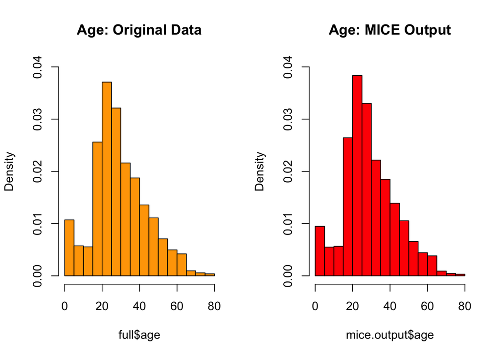

```r
par(mfrow=c(1,2))
hist(full$age, freq=F, main='Age: Original Data', col='orange', ylim=c(0,0.04))
hist(mice.output$age, freq=F, main='Age: MICE Output', col='red', ylim=c(0,0.04))
```

效果不錯！

```r
# 對原年齡數據進行更換
full$age <- mice.output$age
sum(is.na(full$age))
```

```
## [1] 0
```

確認年齡缺失值已全數填補。

# 4 預測生還與否

#### 我使用的是隨機樹，針對原訓練資料做一次預測，效果不錯。

```r
train <- full[1:1000, ]
test <- full[1001:1309,]

set.seed(2018)
rf_model <- randomForest(survived ~ pclass + sex + age + sibsp
                         + parch + fare + embarked + title + familysize + onboat, data = train)
```

```r
prediction.train <- predict(rf_model, train)
correction.rate <- sum(prediction.train == full[1:1000, "survived"]) / 1000
correction.rate
```

```
## [1] 0.99
```

針對原訓練資料，正確率不錯，有99％左右！

### 針對測試資料做預測

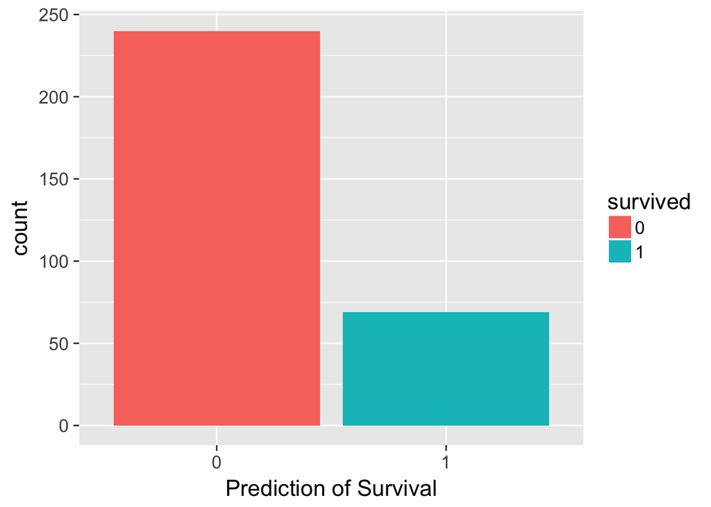

```r
prediction <- predict(rf_model, test)
answer <- data.frame(survived = prediction )

ggplot(answer, aes(x = survived, fill = survived)) +
  geom_bar(stat = 'count') +
  labs(x = 'Prediction of Survival') +
  theme_grey(base_size = 16)
```

看一下生還與罹難人數比較。

### 寫入檔案

```r
write.csv(answer, file = "predict1.csv", row.names = FALSE)
```